# SST Validation and Comparison

We can plot the anomalies as a time series.

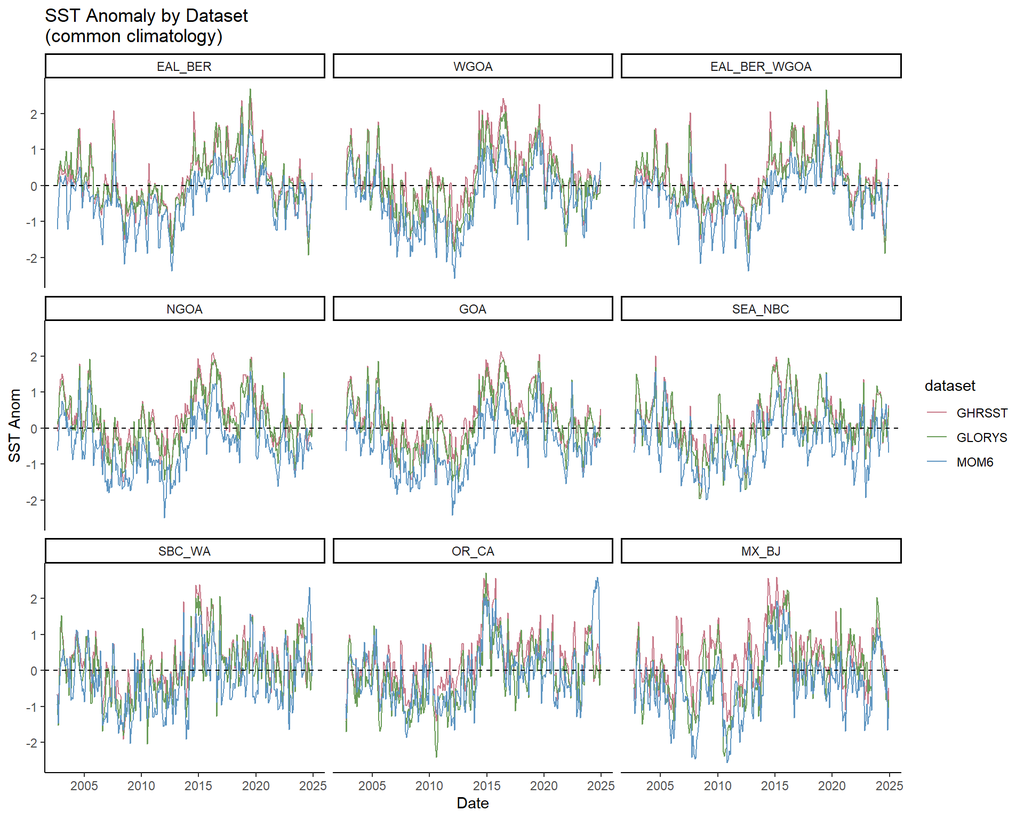

```r
mean_anom_dflong <- mean_anom_df |>
  pivot_longer(GLORYS:MOM6,names_to = "dataset",values_to="sst_anom")
mean_anom2_dflong <- mean_anom2_df |>
  pivot_longer(GLORYS:MOM6,names_to = "dataset",values_to="sst_anom")

anom_ts_p <- mean_anom_dflong |>
  ggplot(aes(date,sst_anom,color=dataset))+
  facet_wrap(~zone_ord)+
  geom_line()+
  geom_hline(yintercept=0,linetype=2)+
  labs(title="SST Anomaly by Dataset\n(common climatology)",x="Date",y="SST Anom")+
  scale_color_manual(values=qualitative_hcl(palette="Dark 2",n=3))

anom2_ts_p <- mean_anom2_dflong |>
  ggplot(aes(date,sst_anom,color=dataset))+
  facet_wrap(~zone_ord)+
  geom_line()+
  geom_hline(yintercept=0,linetype=2)+
  labs(title="SST Anomaly by Dataset\n(dataset-specific climatology)",x="Date",y="SST Anom")+
  scale_color_manual(values=qualitative_hcl(palette="Dark 2",n=3))
anom_ts_p
```

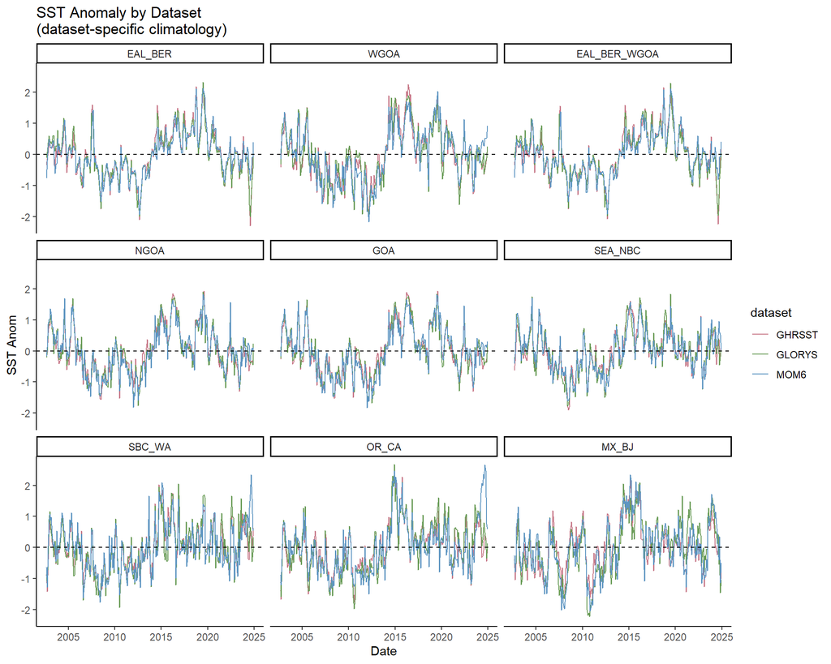

```r
anom2_ts_p
```

## Conclusions

Sea surface temperature from GLORYS, MOM6, and the satellite-derived GHRSST were compared across multiple coastal zones of the Northeast Pacific from the Bering Sea to Mexico. We assessed the correlation, difference/bias, and anomaly correlation between the three datasets. When summarized as monthly anomaly timeseries, the temporal correlation between all the datasets is quite high (>0.8, and >0.92 when using the individual dataset climatologies as the baseline). The correlation at this scale is high among all pairs of datasets across all spatial zones (although correlations are a little lower between MOM6 and the other datasets for the zones from Southeast Alaska to the Oregon and California coast). This likely means that there would be very little difference between datasets if derived indices of interest were calculated in this spatially- and temporally-averaged, mean-centered way. It is clear from the anomaly timeseries that all three datasets are capturing decadal-scale trends, such as the large marine heatwave in the mid-2010s that followed the relatively cooler period from about 2005-2012.

We see a more nuanced picture when we calculate relative differences and correlations between the datasets on a month-by-month basis across regions (sections “Correlation” and “Mean Difference” above). Correlations between datasets for specific months (as opposed to their anomaly correlation across time) are quite low in some places and months. In most zones and months, GLORYS and GHRSST are closely correlated, while MOM6 is less correlated with both other datasets. Correlations generally decline in the summer for the areas from Southeast AK to Southern British Columbia and Washington, suggesting this is a zone of some dynamic disagreement between models. Conversely, in the Gulf of Alaska, the correlations between MOM6 and the other datasets are highest in the summer and fall, and lowest in the winter.

In general, MOM6 is colder than GHRSST and GLORYS. MOM6 is biased cold by ~0.5 to 1 degree in most regions. The Oregon/California and Baja Mexico regions are the exceptions, where GLORYS and MOM6 are in agreement, and both are colder than GHRSST. Across all years, relative bias (difference) between GLORYS and GHRSST is less than 0.5 degrees C in all zones except Baja Mexico. For the Eastern Aleutians and Bering Sea through the Gulf of Alaska, MOM6 is consistently ~0.25-1 degree colder than the other two datasets. In Southeast AK, British Columbia, and Washington, there is a strong seasonal pattern: MOM6 is about 1 degree cooler than GHRSST and GLORYS from October to March, but has near-zero relative bias in the summer. Along the Oregon and California coast, all three datasets agree (near-zero bias) in the spring season, with less agreement in the late summer and fall. Finally, across most zones, the summer season has the most interannual variation in relative bias between datasets.

Overall, these three data sources for sea surface temperature tell similar stories, and at the scale of climate trends and multi-year oceanographic events like heatwaves, all three capture very similar information. For particular spatial regions in particular seasons, there are more substantial differences and less agreement among models, although these differences are normally on the scale of less than 1 degree C.